# Lab 4

Matt Crump

3/4/2021

1. Consider the following example data for a between-subjects experiment with two groups, A and B:

```r
library(tibble)
example_data <- tibble(Group = rep(c("A","B"), each = 5),
                       DV = c(2,4,3,5,4,7,6,5,6,7))
```

Use R to conduct a t.test and ANOVA on this data. Then use R to prove that the results of both analyses are the same. For example, prove that the p-values are the same, and prove that the F-value and T-value are related. (3 points)

```r
my_t <- t.test(DV~Group, var.equal=TRUE, data = example_data)
my_aov <- summary(aov(DV~Group, data = example_data))

my_t$p.value
```

```
## [1] 0.003386143
```

```r
my_aov[[1]]$`Pr(>F)`[1]
```

```
## [1] 0.003386143
```

```r
round(my_t$p.value, digits=5) == round(my_aov[[1]]$`Pr(>F)`[1], digits =5)
```

```
## [1] TRUE
```

```r
my_t$statistic^2
```

```
##    t
## 16.9
```

```r
my_aov[[1]]$`F value`[1]
```

```
## [1] 16.9
```

```r
round(my_t$statistic^2, digits=1) == round(my_aov[[1]]$`F value`[1], digits=1)
```

```
##    t
## TRUE
```

2. Look at the lab on ANOVA that I wrote for our undergraduate statistics OER lab manual https://crumplab.github.io/statisticsLab/lab-8-one-way-anova.html. That lab shows an example of obtaining data from a published paper in psych science where a one-factor ANOVA was used as a part of the analysis. Load the data, conduct the ANOVA, report a ggplot of the means, and use papaja to help you write a short results section reporting the ANOVA result. (3 points).

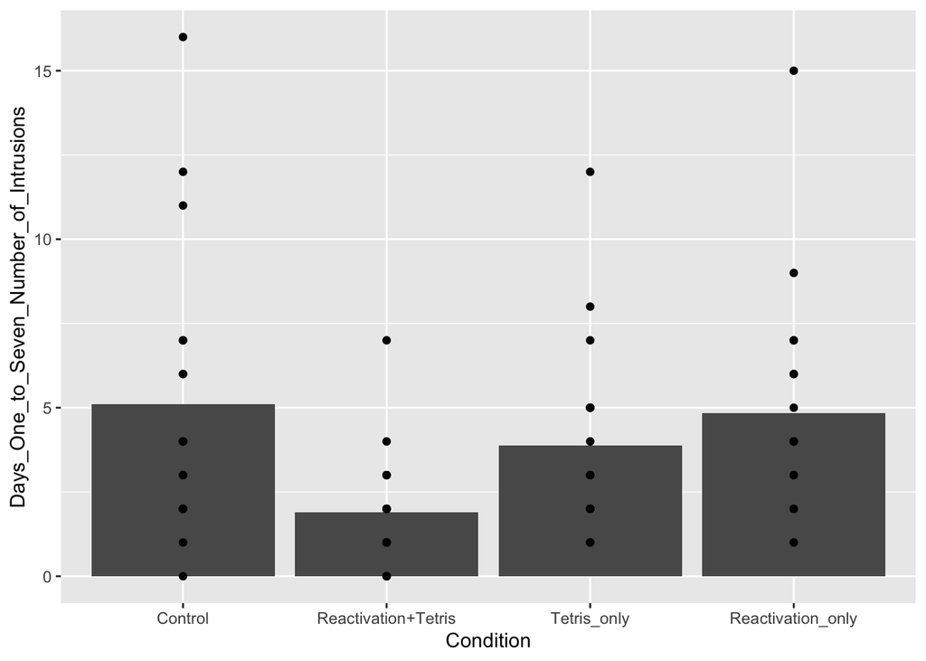

```r
library(data.table)
all_data <- fread("data/Jamesetal2015Experiment2.csv")

# re-labelling

all_data$Condition <- as.factor(all_data$Condition)
levels(all_data$Condition) <- c("Control",
                                "Reactivation+Tetris",
                                "Tetris_only",
                                "Reactivation_only")

library(ggplot2)

ggplot(all_data, aes(x=Condition, y=Days_One_to_Seven_Number_of_Intrusions))+
  geom_bar(stat="summary", fun= "mean", position="dodge")+
  geom_point()
```

```r
my_aov <- aov(Days_One_to_Seven_Number_of_Intrusions~Condition, data = all_data)
summary(my_aov)
```

```
##             Df Sum Sq Mean Sq F value Pr(>F)
## Condition    3  114.8   38.27   3.795 0.0141 *
## Residuals   68  685.8   10.09
## ---
## Signif. codes:  0 '***' 0.001 '**' 0.01 '*' 0.05 '.' 0.1 ' ' 1
```

```r
library(papaja)
#apa_print(my_aov)$full_result$Condition
```

We submitted the mean intrusive memories for the week from each subject in each condition to a one-factor between-subjects ANOVA, with Intervention type (No-task control, Reactivation Plus tetris, Tetris only, Reactivation only) as the sole independent variable. We found a main effect of Intervention type, $F(3, 68) = 3.79$, $\mathit{MSE} = 10.09$, $p = .014$, $\hat{\eta}^2_G = .143$.